# Exemple de manipulation de rasters avec `R` et le package `Terra`

### Créer et exporter les polygones de surface en eau, et comment extraire le lac.

Transformons notre raster binaire vrai / faux en polygone avec `as.polygone()`

```r
NDWI_sv <- as.polygons(NDWI_binaire)
NDWI_sv
```

```
 class       : SpatVector
 geometry    : polygons
 dimensions  : 2, 1  (geometries, attributes)
 extent      : 836950, 909780, 746770, 882010  (xmin, xmax, ymin, ymax)
 coord. ref. : WGS 84 / UTM zone 29N (EPSG:32629)
 names       : T29NRH_20250503T103701_B03
 type        :                      <int>
 values      :                          0
                                        1
```

Dans les résultats, deux objets sont présents, un qui regroupe les polygones vrais et un qui regroupe les polygones faux. La fonction `split()` permet d’éclater les polygones, équivalent de `Multi-parties vers une partie` dans les logiciels de SIG. La documentation nous informe qu’il faut deux fois les mêmes valeurs dans les paramètres.

```r
surface_en_eau <- split(NDWI_sv, NDWI_sv)
```

```r
surface_en_eau <- NDWI_sv[NDWI_sv$T29NRH_20250503T103701_B03 == TRUE]
```

`expense(x, unit = "km")` permet de rajouter les valeurs de surface en kilomètres carrés.

```r
surface_en_eau$surface <- expanse(surface_en_eau, unit = "km")
```

Visualisons les polygones sur un MNT.

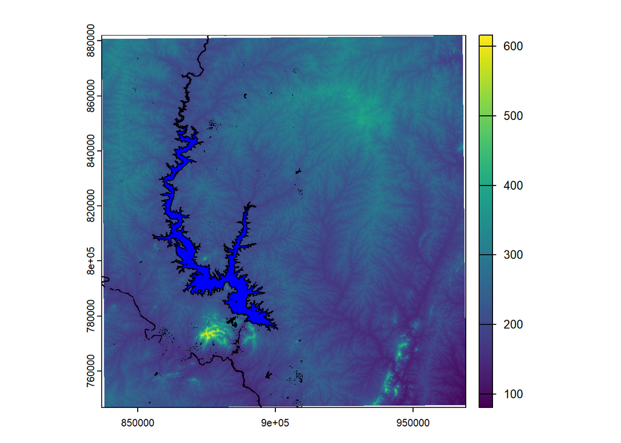

```r
plot(MNT)
plot(surface_en_eau, col = "blue", add = T)
```

```r
max(surface_en_eau)
```

```
T29NRH_20250503T103701_B03                    surface
                    1.0000                   521.4114
```

Exportons les surfaces en eaux dans le format `shapefile`.

```r
terra::writeVector(surface_en_eau, "./data/export/surface_en_eau.shp", overwrite=TRUE)
```

**Méthode `sf`**

```r
library(sf)
NDWI_sf <- st_as_sf(NDWI_sv) # Convertion d'un objet terra en objet sf
NDWI_sf <- st_cast(NDWI_sf, "POLYGONE") # Ëclatement des NDWI_sfgones (multipart to single part dans QGIS)
NDWI_sf$surface <- st_area(NDWI_sf) # Ajout de la colonne surface en m²
NDWI_sf = NDWI_sf[NDWI_sf$T29NRH_20250503T103701_B03 == 1,] # Suppression de tout ce qui n'a pas de valeur 1 dans la première colonne (tout ce qui est false)
plot(NDWI_sf[1], col  = "blue") # Affichage du résultat

NDWI_sf$surface <- units::set_units(NDWI_sf$surface, km^2) # Changement de l'unité m² en km ²
max(NDWI_sf$surface) # La surface du NDWI_sfgone le plus grand, supposément le lac de Kossou.
write_sf(NDWI_sf, "surface_en_eau.shp", overwrite=TRUE) # Exporter les objets dans un format shp
```